# Linear Regression Assignment

Mendoza College of Business-Gayatri Chintala

07/11/2023

# Set Up

```r
load("nba_data.rda") # Load data
```

The dataset we are using contains statistics on NBA games from 2010 to 2021, the features in the data are:

The statistics calculated are:

- fgm - Field goals made
- fga - Field goals attempted
- fg3m - 3 point shots made
- fg3a - 3 point shots attempted
- fg2m - 2 point shots made
- fg2a - 2 point shots attempted
- ftm - Free throws made
- fta - Free throws attempted
- oreb - Offensive rebounds
- dreb - Defensive rebounds
- treb - Total rebounds
- ast - Assists
- stl - Steals
- blk - Blocks
- tov - Turnovers
- pf - Personal fouls
- pts - Points scored
- pctfg - Field goal percentage
- pctfg2 - 2 point field goal percentage
- pctfg3 - 3 point field goal percentage
- pctft - Free throw percentage

These are calculated for the different aspects of the match-up denoted by the following adjustments to the variable names:

- _1_off - Offensive stats for team 1 in previous games
- _1_def - Defensive stats for team 1 in previous games (That is stats from team 1’s opponents)
- _2_off - Offensive stats for team 2 in previous games
- _2_def - Defensive stats for team 2 in previous games (That is stats from team 2’s opponents)

There is also an ELO rating function which can be used to provide a ranking of the teams:

https://medium.com/purple-theory/what-is-elo-rating-c4eb7a9061e0

The objective of our analysis is to determine the key factors involved in winning NBA games, so we will use point differential as our response variable.

```r
# Create response variable
nba_data$point_diff <- nba_data$team_1_points - nba_data$team_2_points
```

Before running the model we want to drop all of the unique identifiers for the games and the points used to calculate the differential:

```r
# Drop columns
nba_model <- nba_data[,c(8:91, 94:96)]
```

# Assignment

Please complete the following tasks and answer the following questions:

- 1 - Create two visualizations which may reveal interesting relationships in the dataset. Describe what you see in the visualization. (2 Points)

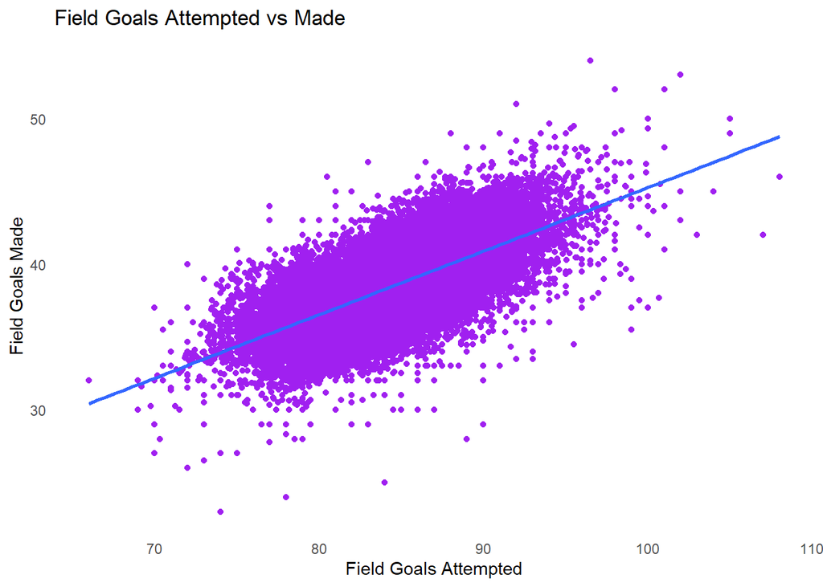

```r
log_goals_made <- log(nba_model$fgm_1_off+1)

library(ggplot2)

my_plot1 <- ggplot(nba_model, aes(x=fga_1_off, y=fgm_1_off)) +
  geom_point(aes(color=fga_1_off), color = "purple") +
  geom_smooth(method = "lm") +
  labs(title="Field Goals Attempted vs Made",
       x="Field Goals Attempted",
       y="Field Goals Made") +
  theme_minimal() +
  theme(panel.grid.major = element_blank(),
        panel.grid.minor = element_blank(),
        panel.border = element_blank(),
        panel.background = element_blank())

my_plot1 # Generate plot
```

Answer: The relationship between field goals made and field goals attempted of team 1 offense, proves to be a positive relationship. It indicates that the more number of times a goal is attempted the more likely it is to happen.

[figure not shown]

```r
my_plot2 <- ggplot(nba_model, aes(x=fga_2_off, y=ftm_2_off)) +
  geom_point(aes(color=fga_1_off), color = "green") +
  geom_smooth(method = "lm") +
  labs(title="Field Goals Attempted vs Made",
       x="Field Goals Attempted",
       y="Field Goals Made") +
  theme_minimal() +
  theme(panel.grid.major = element_blank(),
        panel.grid.minor = element_blank(),
        panel.border = element_blank(),
        panel.background = element_blank())

my_plot2 # Generate plot
```

- 2 - Run a linear regression model on the dataset using `point_diff` as the response variable and all other variables in the model data as explanatory variables. (1 Point)

```r
lm_1 <- lm(point_diff~.,
            data = nba_model)
summary(lm_1)
```

```
##
## Call:
## lm(formula = point_diff ~ ., data = nba_model)
##
## Residuals:
##     Min      1Q  Median      3Q     Max
## -57.249  -8.270  -0.001   8.290  57.911
##
## Coefficients: (16 not defined because of singularities)
##                Estimate Std. Error t value Pr(>|t|)
## (Intercept)  -1.683e+01  6.866e+01  -0.245 0.806317
## fgm_1_off     1.347e+00  8.183e-01   1.646 0.099747 .
## fga_1_off    -7.241e-01  3.838e-01  -1.887 0.059211 .
## fg3m_1_off   -5.723e-01  4.469e-01  -1.281 0.200335
## fg3a_1_off    4.471e-01  2.044e-01   2.187 0.028728 *
## fg2m_1_off           NA         NA      NA       NA
## fg2a_1_off           NA         NA      NA       NA
## ftm_1_off     3.031e-02  4.742e-01   0.064 0.949034
## fta_1_off    -1.374e-02  3.657e-01  -0.038 0.970027
## oreb_1_off    2.764e-01  8.899e-02   3.106 0.001901 **
## dreb_1_off    2.203e-01  6.430e-02   3.426 0.000614 ***
## treb_1_off           NA         NA      NA       NA
## ast_1_off     1.202e-01  4.380e-02   2.745 0.006058 **
## stl_1_off     3.867e-01  9.299e-02   4.158 3.22e-05 ***
## blk_1_off     1.854e-01  7.991e-02   2.320 0.020326 *
## tov_1_off    -3.675e-01  8.572e-02  -4.287 1.82e-05 ***
## pf_1_off      1.373e-01  6.597e-02   2.081 0.037457 *
## pts_1_off            NA         NA      NA       NA
## pctfg_1_off  -5.284e+01  6.495e+01  -0.814 0.415874
## pctfg2_1_off -2.064e+01  2.217e+01  -0.931 0.351977
## pctfg3_1_off  5.612e+00  7.233e+00   0.776 0.437773
## pctft_1_off   7.841e+00  1.130e+01   0.694 0.487711
## fgm_1_def    -2.781e+00  9.925e-01  -2.802 0.005079 **
## fga_1_def     1.301e+00  4.659e-01   2.793 0.005230 **
## fg3m_1_def    8.153e-01  6.714e-01   1.214 0.224605
## fg3a_1_def   -4.456e-01  3.046e-01  -1.463 0.143534
## fg2m_1_def           NA         NA      NA       NA
## fg2a_1_def           NA         NA      NA       NA
## ftm_1_def    -6.687e-01  6.736e-01  -0.993 0.320889
## fta_1_def     3.766e-01  5.150e-01   0.731 0.464626
```

[output cut: 49 more lines]

```
## pf_2_def     -1.319e-01  9.395e-02  -1.404 0.160252
## pts_2_def            NA         NA      NA       NA
## pctfg_2_def  -1.361e+02  7.679e+01  -1.773 0.076249 .
## pctfg2_2_def -3.649e+01  3.437e+01  -1.062 0.288339
## pctfg3_2_def -1.045e+01  1.070e+01  -0.977 0.328546
## pctft_2_def  -2.188e+01  1.611e+01  -1.359 0.174287
## elo_2        -2.418e-02  1.713e-03 -14.117  < 2e-16 ***
## elo_1         2.583e-02  1.649e-03  15.668  < 2e-16 ***
## ---
## Signif. codes:  0 '***' 0.001 '**' 0.01 '*' 0.05 '.' 0.1 ' ' 1
##
## Residual standard error: 12.77 on 27895 degrees of freedom
##   (430 observations deleted due to missingness)
## Multiple R-squared:  0.157,  Adjusted R-squared:  0.1549
## F-statistic: 74.21 on 70 and 27895 DF,  p-value: < 2.2e-16
```

- 3 - What features in the model were significant (At 0.1% level)? Do these variables have a positive or negative effect on a teams change of winning a game? (1 Point)

Answer: The features in the model that are significant at 0.1% are, dreb_1_off(+ve), stl_1_off(+ve), tov_1_off(-ve), ast_1_def(-ve), ast_2_def(+ve), elo_2(-ve), and elo_1(+ve).

The variables that have a positive impact on a teams change of winning a game are: dreb_1_off stl_1_off ast_2_def elo_1

The variables that have a negative impact on a teams change of winning a game are: tov_1_off ast_1_def elo_2

- 4 - Visualize two potential interaction terms and their relationship with the response variable. Are these interaction terms likely to have a significant relationship with the response variable? (2 Points)

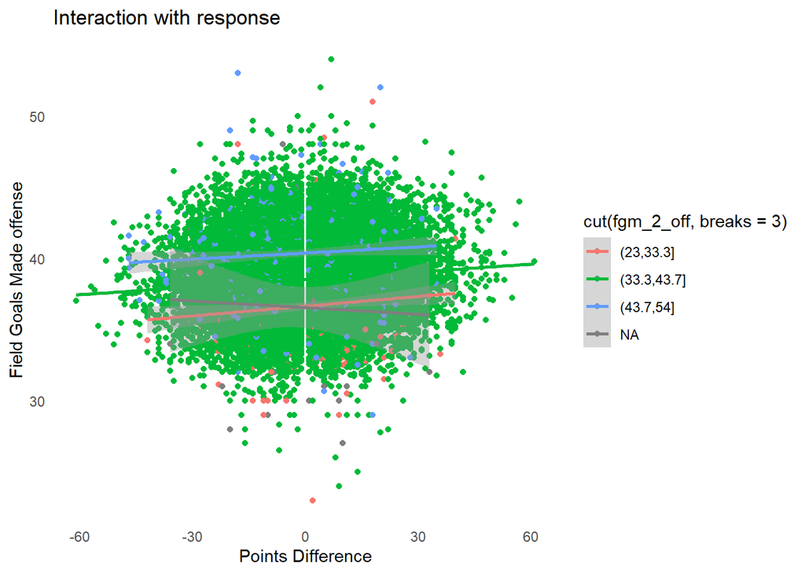

```r
my_plot3 <- ggplot(nba_model, aes(x=point_diff, y=fgm_1_off, color=cut(fgm_2_off, breaks = 3))) +
  geom_point() +
  geom_smooth(method = "lm") +
  labs(title="Interaction with response",
       x="Points Difference",
       y="Field Goals Made offense") +
  theme_minimal() +
  theme(panel.grid.major = element_blank(),
        panel.grid.minor = element_blank(),
        panel.border = element_blank(),
        panel.background = element_blank())

my_plot3 # Generate plot
```

Answer: The interaction terms that I used show a slight positive relation with the response variable.

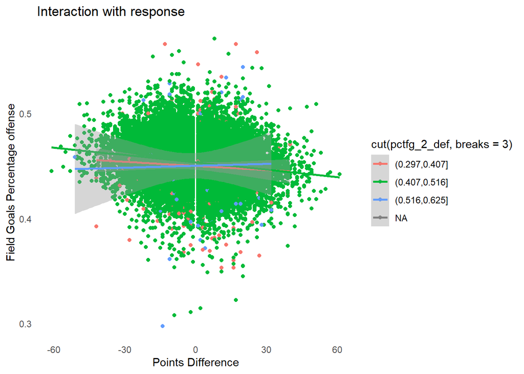

```r
my_plot4 <- ggplot(nba_model, aes(x=point_diff, y=pctfg_2_off, color=cut(pctfg_2_def, breaks = 3))) +
  geom_point() +
  geom_smooth(method = "lm") +
  labs(title="Interaction with response",
       x="Points Difference",
       y="Field Goals Percentage offense") +
  theme_minimal() +
  theme(panel.grid.major = element_blank(),
        panel.grid.minor = element_blank(),
        panel.border = element_blank(),
        panel.background = element_blank())

my_plot4 # Generate plot
```

Answer: The other interaction term that I used, show a slightly negative regression line/relationship with the response variable.

- 5 - Fit a linear regression model with the two interaction terms included. (1 Point)

```r
lm_interaction_terms <- lm(point_diff~ . +fgm_1_off*fgm_2_off + pctfg_2_off*pctfg_2_def, data = nba_model)
summary(lm_interaction_terms)
```

```
##
## Call:
## lm(formula = point_diff ~ . + fgm_1_off * fgm_2_off + pctfg_2_off *
##     pctfg_2_def, data = nba_model)
##
## Residuals:
##     Min      1Q  Median      3Q     Max
## -57.196  -8.263  -0.003   8.280  57.978
##
## Coefficients: (16 not defined because of singularities)
##                           Estimate Std. Error t value Pr(>|t|)
## (Intercept)             -3.576e+01  7.296e+01  -0.490 0.624000
## fgm_1_off                1.117e+00  1.056e+00   1.058 0.290105
## fga_1_off               -6.919e-01  3.931e-01  -1.760 0.078385 .
## fg3m_1_off              -5.881e-01  4.511e-01  -1.304 0.192367
## fg3a_1_off               4.545e-01  2.063e-01   2.203 0.027610 *
## fg2m_1_off                      NA         NA      NA       NA
## fg2a_1_off                      NA         NA      NA       NA
## ftm_1_off                2.848e-02  4.742e-01   0.060 0.952121
## fta_1_off               -1.202e-02  3.657e-01  -0.033 0.973780
## oreb_1_off               2.764e-01  8.899e-02   3.106 0.001896 **
## dreb_1_off               2.207e-01  6.435e-02   3.430 0.000605 ***
## treb_1_off                      NA         NA      NA       NA
## ast_1_off                1.197e-01  4.381e-02   2.731 0.006314 **
## stl_1_off                3.884e-01  9.307e-02   4.173 3.02e-05 ***
## blk_1_off                1.856e-01  7.994e-02   2.322 0.020263 *
## tov_1_off               -3.692e-01  8.576e-02  -4.305 1.68e-05 ***
## pf_1_off                 1.371e-01  6.597e-02   2.078 0.037698 *
## pts_1_off                       NA         NA      NA       NA
## pctfg_1_off             -4.590e+01  6.787e+01  -0.676 0.498902
## pctfg2_1_off            -2.127e+01  2.231e+01  -0.954 0.340308
## pctfg3_1_off             5.770e+00  7.250e+00   0.796 0.426125
## pctft_1_off              7.912e+00  1.130e+01   0.700 0.483807
## fgm_1_def               -2.819e+00  9.938e-01  -2.837 0.004561 **
## fga_1_def                1.318e+00  4.665e-01   2.826 0.004720 **
## fg3m_1_def               8.249e-01  6.718e-01   1.228 0.219501
## fg3a_1_def              -4.507e-01  3.048e-01  -1.479 0.139225
## fg2m_1_def                      NA         NA      NA       NA
## fg2a_1_def                      NA         NA      NA       NA
## ftm_1_def               -6.906e-01  6.743e-01  -1.024 0.305770
```

[output cut: 52 more lines]

```
## pctfg_2_def             -9.285e+01  9.497e+01  -0.978 0.328242
## pctfg2_2_def            -3.501e+01  3.442e+01  -1.017 0.309123
## pctfg3_2_def            -1.001e+01  1.071e+01  -0.934 0.350118
## pctft_2_def             -2.144e+01  1.612e+01  -1.330 0.183510
## elo_2                   -2.420e-02  1.716e-03 -14.104  < 2e-16 ***
## elo_1                    2.581e-02  1.649e-03  15.651  < 2e-16 ***
## fgm_1_off:fgm_2_off      4.135e-03  1.237e-02   0.334 0.738120
## pctfg_2_off:pctfg_2_def -1.201e+02  1.586e+02  -0.757 0.449053
## ---
## Signif. codes:  0 '***' 0.001 '**' 0.01 '*' 0.05 '.' 0.1 ' ' 1
##
## Residual standard error: 12.77 on 27893 degrees of freedom
##   (430 observations deleted due to missingness)
## Multiple R-squared:  0.157,  Adjusted R-squared:  0.1548
## F-statistic: 72.16 on 72 and 27893 DF,  p-value: < 2.2e-16
```

- 6 - How has the inclusion of the interaction terms affected the coefficients in the model? How has the inclusion of interaction terms affected the model fit? (1 Point)

2 Points for code quality and analysis decisions.